# Alternate versions of Figure 5 from Ford et al. (2017)

Keegan Korthauer

April 29, 2018

# 1 Summary

Code to download and analyze the processed methylation count data from the Lister Lab paper by Ford et al., “Frequent lack of repressive capacity of promoter DNA methylation identified through genome-wide epigenomic manipulation” ( available on [BioRxiv](https://www.biorxiv.org/content/early/2017/09/20/170506)).

The WGBS methylation counts for all cytosines are provided on GEO (accession number GSE102395).

# 2 Workspace Setup

First we load the necessary packages.

```r
library(GEOquery)
library(data.table)
library(dplyr)
library(tidyr)
library(GenomicRanges)
library(ggplot2)
library(R.utils)
library(DESeq2)
library(annotatr)
library(bsseq)
library(dmrseq)
library(BiocParallel)
library(chunked)
library(DelayedMatrixStats)

# data directory
datdir <- "DATA"
dir.create(datdir, showWarnings = FALSE)

# rscript directory
rdir <- "R/"
sourceDirectory(rdir)

# results directory
resdir <- "RESULTS"
dir.create(resdir, showWarnings = FALSE)

# parallel backend
ncores <- 6
register(MulticoreParam(workers=ncores))

# FDR significance levels for differential expression and DMR analyses
fdrlevel.dmr <- 0.05
fdrlevel.de <- 0.05
```

# 3 Data download

We will download the cytosine methylation counts for the following WGBS samples:

> GSM2735962 MCF7_emptyVector_doxInduced_rep1_WGBS GSM2735963 MCF7_empytVector_doxWithdrawn_rep1_WGBS GSM2735964 MCF7_ZF_DNMT3A_doxInduced_rep1_WGBS GSM2735965 MCF7_ZF_DNMT3A_doxInduced_rep2_WGBS GSM2735966 MCF7_ZF_DNMT3A_doxInduced_rep3_WGBS GSM2735967 MCF7_ZF_DNMT3A_doxWithdrawn_rep1_WGBS GSM2735968 MCF7_ZF_DNMT3A_doxWithdrawn_rep2_WGBS GSM2735969 MCF7_ZF_DNMT3A_noDox_rep1_WGBS

As well as the expression counts. First we get the cytosine methylation counts. Since we are only interested in the CpG methylation context, we also filter these files by rows where the 4th column is equal to `CG`. This step requires that the system has the `awk` command available.

```r
# methylation counts
meta = pData(phenoData(getGEO("GSE102395")[[1]]))
```

```
## Found 1 file(s)
```

```
## GSE102395_series_matrix.txt.gz
```

```
## File stored at:
```

```
## /tmp/Rtmpcx32UG/GPL18460.soft
```

```r
filePaths <- as.character(meta$supplementary_file_1[grepl("WGBS", meta$description)])
corrupt <- NULL

for (file in filePaths){
  fi <- file.path(datdir,
              sapply(strsplit(file, "/"), function(x) x[length(x)]))
  err <- gsub(".gz", "", fi)
  if (!file.exists(fi) && !file.exists(gsub(".gz", "", fi))){
    download.file(url = file, destfile = fi)
  }

  if (!file.exists(gsub(".gz", "", fi))){
    err <- try(gunzip(fi), silent = TRUE)
  }

  if (err==gsub(".gz", "", fi)){
    message("Downloaded and unzipped file ", fi)

    if (!file.exists(gsub("allC", "CpG", gsub(".gz", "", fi)))){
      system(paste0("awk '($4 == \"CG\")' ", gsub(".gz", "", fi),
                  " > ", gsub("allC", "CpG", gsub(".gz", "", fi))))
    }
    message("CpGs filtered for file ", gsub("allC", "CpG", gsub(".gz", "", fi)))
  }else{
    message(err)
    message("Skipping file ", fi, " since it is corrupt.")
    corrupt <- c(corrupt, fi)
    file.remove(fi)
  }
}
```

```
## Downloaded and unzipped file DATA/GSM2735962_MCF7_emptyVector_doxInduced_rep1.allC.txt.gz
```

```
## CpGs filtered for file DATA/GSM2735962_MCF7_emptyVector_doxInduced_rep1.CpG.txt
```

```
## Downloaded and unzipped file DATA/GSM2735963_MCF7_empytVector_doxWithdrawn_rep1.allC.txt.gz
```

```
## CpGs filtered for file DATA/GSM2735963_MCF7_empytVector_doxWithdrawn_rep1.CpG.txt
```

```
## Downloaded and unzipped file DATA/GSM2735964_MCF7_ZF_DNMT3A_doxInduced_rep1.allC.txt.gz
```

```
## CpGs filtered for file DATA/GSM2735964_MCF7_ZF_DNMT3A_doxInduced_rep1.CpG.txt
```

```
## Downloaded and unzipped file DATA/GSM2735965_MCF7_ZF_DNMT3A_doxInduced_rep2.allC.txt.gz
```

```
## CpGs filtered for file DATA/GSM2735965_MCF7_ZF_DNMT3A_doxInduced_rep2.CpG.txt
```

```
## Downloaded and unzipped file DATA/GSM2735966_MCF7_ZF_DNMT3A_doxInduced_rep3.allC.txt.gz
```

```
## CpGs filtered for file DATA/GSM2735966_MCF7_ZF_DNMT3A_doxInduced_rep3.CpG.txt
```

```
## Downloaded and unzipped file DATA/GSM2735967_MCF7_ZF_DNMT3A_doxWithdrawn_rep1.allC.txt.gz
```

```
## CpGs filtered for file DATA/GSM2735967_MCF7_ZF_DNMT3A_doxWithdrawn_rep1.CpG.txt
```

```
## Downloaded and unzipped file DATA/GSM2735968_MCF7_ZF_DNMT3A_doxWithdrawn_rep2.allC.txt.gz
```

```
## CpGs filtered for file DATA/GSM2735968_MCF7_ZF_DNMT3A_doxWithdrawn_rep2.CpG.txt
```

```
## Downloaded and unzipped file DATA/GSM2735969_MCF7_ZF_DNMT3A_noDox_rep1.allC.txt.gz
```

```
## CpGs filtered for file DATA/GSM2735969_MCF7_ZF_DNMT3A_noDox_rep1.CpG.txt
```

```r
if (length(corrupt) == 1){
  if (!file.exists(corrupt) && !file.exists(gsub(".gz", "", corrupt))){
     download.file(url = "http://cpebrazor.ivec.org/public/listerlab/ethan/Public/MCF7_ZF_DNMT3A_doxInduced_rep2.allC.gz",
       destfile = corrupt)
  }
  err <- gsub(".gz", "", corrupt)
  if (!file.exists(gsub(".gz", "", corrupt))){
     err <- try(gunzip(corrupt), silent = TRUE)
  }

  if (err==gsub(".gz", "", corrupt)){
    message("Downloaded and unzipped file ", corrupt)

    if (!file.exists(gsub("allC", "CpG", gsub(".gz", "", corrupt)))){
      system(paste0("awk '($4 == \"CG\")' ", gsub(".gz", "", corrupt),
                  " > ", gsub("allC", "CpG", gsub(".gz", "", corrupt))))
    }
    message("CpGs filtered for file ", gsub("allC", "CpG", gsub(".gz", "", corrupt)))
  }
}else if (length(corrupt) > 1){
  stop("More than one file is corrupt")
}else{
  message("All files downloaded and unzipped")
}
```

```
## All files downloaded and unzipped
```

Next, we download the expression count matrix.

```r
# expression counts
file <- file.path(datdir, "GSE102395_MCF7_ZF_DNMT3A_countstable.txt")

if (!file.exists(file)){
  download.file(url = "ftp://ftp.ncbi.nlm.nih.gov/geo/series/GSE102nnn/GSE102395/suppl/GSE102395%5FMCF7%5FZF%5FDNMT3A%5Fcountstable%2Etxt%2Egz",
              destfile = paste0(file, ".gz"),
              mode="wb")
  gunzip(paste0(file, ".gz"))
}
```

# 4 Read in data tables

Now we’ll read in the methylation count tables and convert them to bsseq objects. This uses the `read.lister` function sourced in by the script in the `R` directory.

```r
bfile <- file.path(datdir, "bsseq.rds")

if (!file.exists(bfile)){
  files <- list.files(datdir, pattern = ".CpG.txt", full.names = TRUE)

  bs <- read.lister(files, sampleNames = files, rmZeroCov = TRUE,
                    strandCollapse = TRUE, mc.cores = ncores)
  if ("BSseq" %in% class(bs)){
    saveRDS(bs, bfile)
  }
}else{
  bs <- readRDS(bfile)
}

show(bs)
```

```
## An object of type 'BSseq' with
##   27235993 methylation loci
##   8 samples
## has not been smoothed
## All assays are in-memory
```

We’ll add the metadata so we can easily access the condition information in further analyses.

```r
if(ncol(pData(bs))==0){
  sampleNames(bs) <- unlist(sapply(strsplit(sampleNames(bs), "//"),
                                   function(x) x[[2]]))
  sampleNames(bs) <- unlist(sapply(strsplit(sampleNames(bs), ".CpG"),
                                 function(x) x[[1]]))
  meta$basefile <- unlist(sapply(strsplit(as.character(meta$supplementary_file_1),
                                          "suppl/"), function(x) x[[length(x)]]))
  meta$basefile <- unlist(sapply(strsplit(meta$basefile, ".allC"),
                                 function(x) x[[1]]))

  pdat <- meta[meta$basefile %in% sampleNames(bs),] %>%
    mutate(condition = ifelse(grepl("Vector", source_name_ch1),
                              "Control", "Methylated"),
           dox = ifelse(grepl("noDox", source_name_ch1), "No DOX",
                        ifelse(grepl("doxInduced", source_name_ch1), "DOX",
                               "Dox Withdrawal")))
  pData(bs) <- pdat
  saveRDS(bs, bfile)
}
```

## 4.1 Exploratory analysis

Plots of coverage by sample:

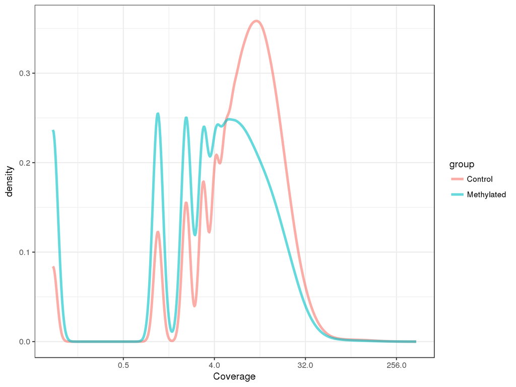

```r
set.seed(486)
idx <- sample(1:nrow(bs), 1e6)
plotEmpiricalDistribution(bs[idx,],
                          testCovariate = "condition",
                          type = "Cov")
```

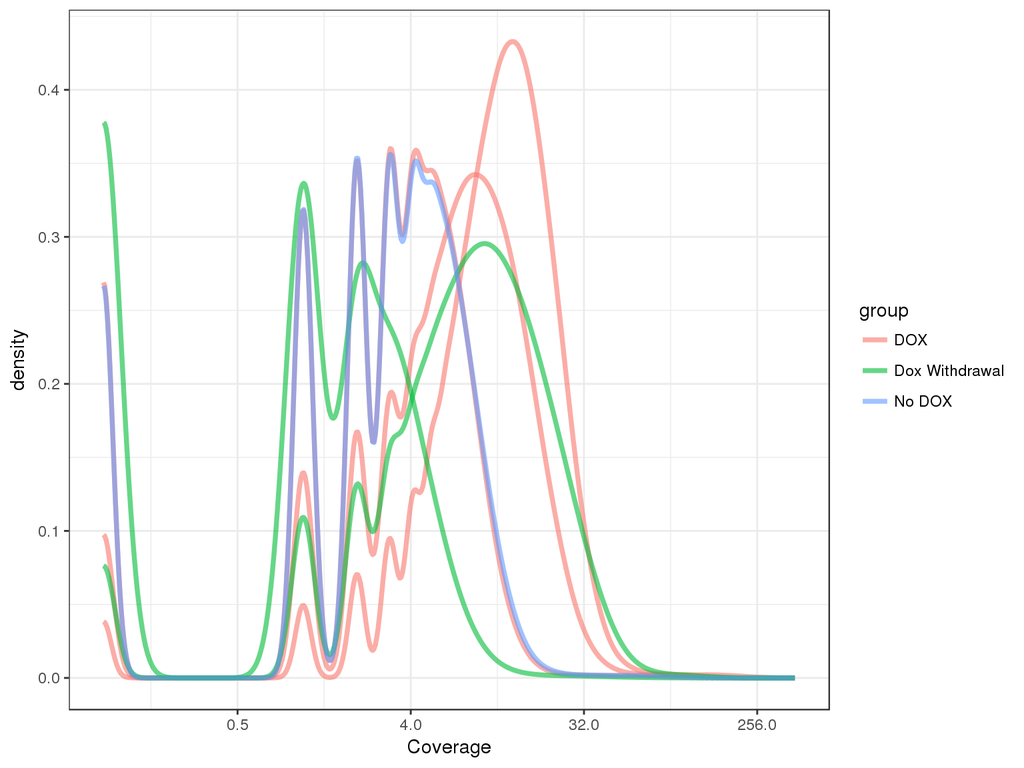

```r
plotEmpiricalDistribution(bs[idx, pData(bs)$condition=="Methylated"],
                          testCovariate = "dox",
                          bySample = TRUE,
                          type = "Cov")
```

Plots of beta values by sample:

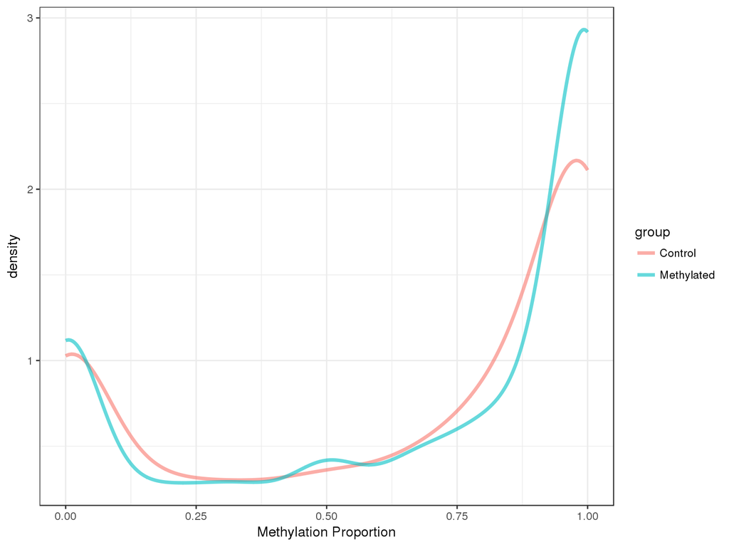

```r
plotEmpiricalDistribution(bs[idx,],
                          testCovariate = "condition",
                          adj = 4)
```

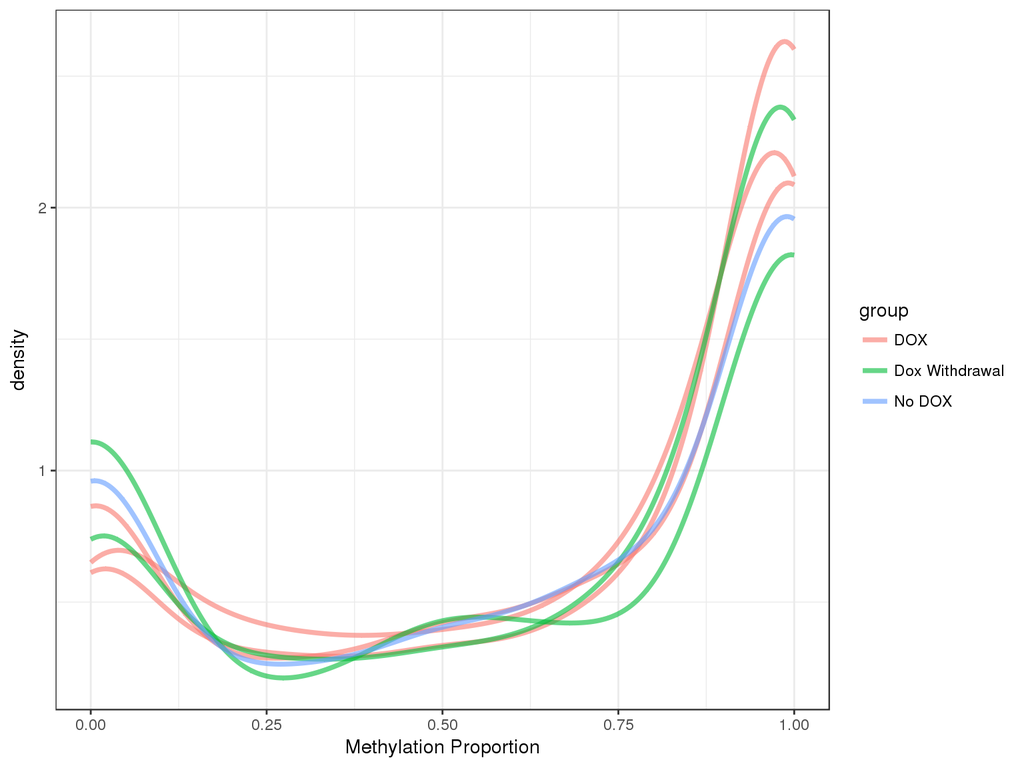

```r
plotEmpiricalDistribution(bs[idx, pData(bs)$condition=="Methylated"],
                          testCovariate = "dox",
                          bySample = TRUE,
                          adj = 4)
```

# DMR analysis

We will use dmrseq to identify Differentially Methylated Regions (DMRs).

First we filter on the samples we will use for the analysis. Specifically, we’ll keep only the control samples and the DOX-induced samples with the MCF7-ZF vector.

```r
bs <- bs[,pData(bs)$condition == "Control" |
          pData(bs)$dox == "DOX"]
```

Next we have to filter the loci by coverage (remove those with zero coverage in at least one condition).

```r
cov.mat <- getCoverage(bs, type="Cov")
filter <- pmax( 1*(rowSums2(cov.mat[,pData(bs)$condition == "Control"]) == 0),
                1*(rowSums2(cov.mat[,pData(bs)$condition == "Methylated"]) == 0))
filter <- which(filter > 0)
bs <- bs[-filter,]
rm(cov.mat)
```

```r
resfile <- file.path(resdir, "regions.rds")

if (!file.exists(resfile)){
  regions <- dmrseq(bs, testCovariate = "condition",
                    bpSpan = 500,
                    maxGap = 500,
                    maxPerms = 4)
  saveRDS(regions, file=resfile)
}else{
  regions <- readRDS(resfile)
}

# sort on qval overall (currently sorted within chromsome)
regions <- regions[order(regions$qval, seqnames(regions)),]

sum(regions$qval < fdrlevel.dmr)
```

```
## [1] 10557
```

We’ll add the raw mean methylation differences to the region summaries and plot the top 20 regions.

```r
regions$meanDiff <- meanDiff(bs, dmrs=regions, testCovariate="condition")

pdf(file.path(resdir, "dmrseq.dmrs.pdf"), width=8, height=3.5)
plotDMRs(bs, regions=regions[1:20,], testCovariate="condition")
```

```
## [plotDMRs] Plotting  DMRs
```

```r
plotDMRs(bs, regions=tail(regions[regions$qval < fdrlevel.dmr,]), testCovariate="condition")
```

```
## [plotDMRs] Plotting  DMRs
```

```r
dev.off()
```

Next, we’ll look at the overlap of the dmrseq DMRs with the DSS DMRs provided by the authors.

```r
dssfile <- paste0(datdir, "170506-2.txt")
if (!file.exists(dssfile)){
  download.file(url = "https://www.biorxiv.org/highwire/filestream/57972/field_highwire_adjunct_files/1/170506-2.txt",
              destfile =  dssfile)
}

dmrs.dss <- fread(dssfile, header=FALSE)  #DMRs
colnames(dmrs.dss) <- c("chr", "start", "end", "number_of_CpG_cytosines_in_region",
                   "methylation_level_in_MCF7_control", "methylation_level_in_ZF_D3A_plus_dox",
                   "methylation_level_in_ZF_D3A_dox_wd", "closest_gene_promoter",
                   "distance_to_nearest_promoter", "promoter_classification",
                   "CpGisland_classification", "genebody_classification",
                   "enhancer_classification")

dmrs.dss <- makeGRangesFromDataFrame(dmrs.dss, keep.extra.columns = TRUE)
dmrs.dss$meanDiff <- meanDiff.dss(bs, dmrs=dmrs.dss, testCovariate="condition")

ol <- findOverlaps(regions[regions$qval < fdrlevel.dmr, ], dmrs.dss)
```

A couple of plots to compare the characteristics of regions found by DSS and dmrseq.

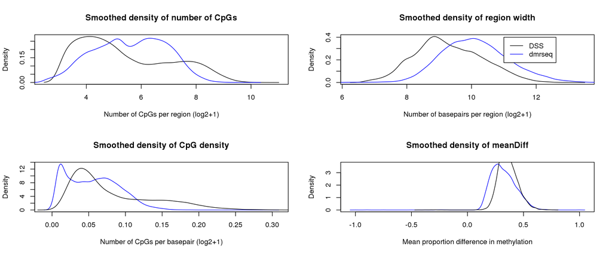

```r
par(mfrow=c(2,2))
plot(density(log2(dmrs.dss$number_of_CpG_cytosines_in_region+1)),
     main = "Smoothed density of number of CpGs",
     xlab = "Number of CpGs per region (log2+1)")
lines(density(log2(regions[regions$qval < fdrlevel.dmr, ]$L+1)), col="blue")

plot(density(log2(width(dmrs.dss)+1)),
     main = "Smoothed density of region width",
     xlab = "Number of basepairs per region (log2+1)")
lines(density(log2(width(regions[regions$qval < fdrlevel.dmr, ])+1)), col="blue")

legend(11, 0.4, legend=c("DSS", "dmrseq"), col=c("black", "blue"), lty=c(1,1))

plot(density((regions[regions$qval < fdrlevel.dmr, ]$L /
                     width(regions[regions$qval < fdrlevel.dmr, ]))),
     col="blue",
     main = "Smoothed density of CpG density",
     xlab = "Number of CpGs per basepair (log2+1)")
lines(density((dmrs.dss$number_of_CpG_cytosines_in_region/width(dmrs.dss))))

plot(density(regions[regions$qval < fdrlevel.dmr, ]$meanDiff),
     main = "Smoothed density of meanDiff",
     xlab = "Mean proportion difference in methylation",
     col="blue")
lines(density(dmrs.dss$meanDiff))
```

# 5 DE analysis

First we need to run the differential expression analysis.

```r
exp <- fread(file.path(datdir, "GSE102395_MCF7_ZF_DNMT3A_countstable.txt"))

# There are duplicate genes -- looks like a classic excel conversion error -- remove these
dup <- which(table(exp$gene) > 1)
names(dup)
```

```
## [1] "Mar-01" "Mar-02"
```

```r
exp <- exp %>% filter(!(gene %in% names(dup)))

# move genes to rownames
rownames(exp) <- exp$gene
exp <- as.matrix(exp %>% dplyr::select(-gene))
allZero <- rowSums(exp==0)==ncol(exp)
exp <- exp[!allZero,]

# strings to match the two comparison samples - control and ZF + DOX
ctrl <- "MCF7_emptyVector"
trt <- "MCF7_ZF_DNMT3A_DOX_rep"

# set up colData
coldata <- data.frame(sample=colnames(exp)) %>%
  mutate(condition = ifelse(grepl(ctrl, sample), "Control",
                     ifelse(grepl(trt, sample), "Methylated", "Other")))

dds <- DESeqDataSetFromMatrix(countData = exp,
                              colData = coldata,
                              design = ~ condition)
```

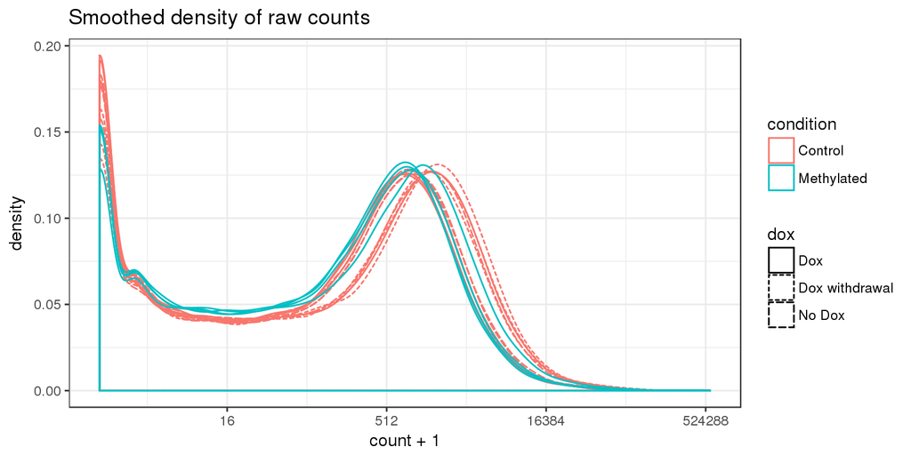

```r
dds <- dds[, dds$condition != "Other"]
dds$condition <- droplevels(dds$condition)
dds <- estimateSizeFactors(dds)

# plot distribution of expression values
exp <- data.frame(counts(dds)) %>%
  gather(sample, count) %>%
  mutate(normcount = (data.frame(counts(dds, normalize=TRUE)) %>%
           gather(sample, count))$count) %>%
  mutate(condition = ifelse(grepl(ctrl, sample), "Control", "Methylated")) %>%
  mutate(dox = ifelse(grepl("noDOX", sample), "No Dox",
                      ifelse(grepl("DOXremoval", sample), "Dox withdrawal",
                             "Dox")))

ggplot(exp, aes(x=count+1, group=sample, color=condition)) +
  geom_density(adjust=0.75, aes(linetype=dox)) +
  scale_x_continuous(trans="log2") +
  theme_bw() +
  ggtitle("Smoothed density of raw counts")
```

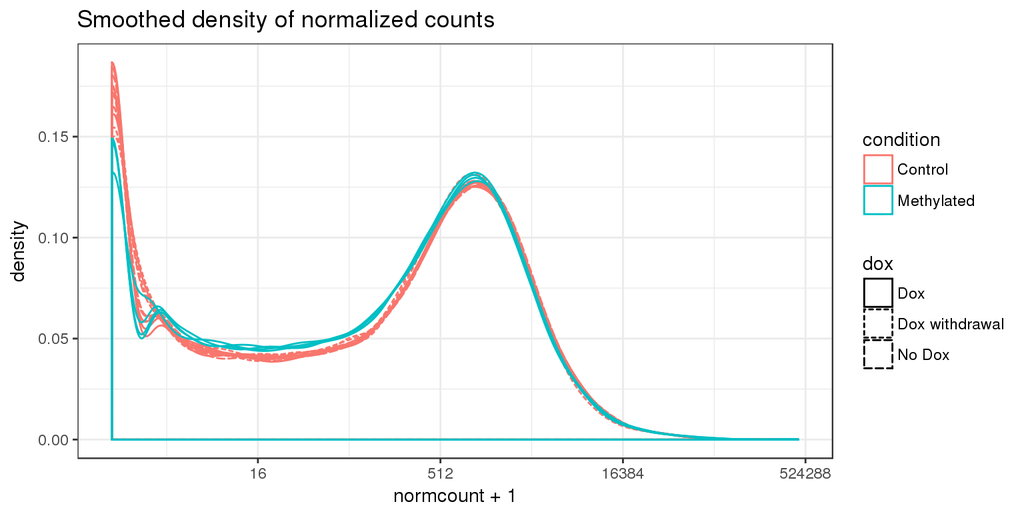

```r
ggplot(exp, aes(x=normcount+1, group=sample, color=condition)) +
  geom_density(adjust=0.75, aes(linetype=dox)) +
  scale_x_continuous(trans="log2") +
  theme_bw() +
  ggtitle("Smoothed density of normalized counts")
```

```r
# collapse over samples of the same dox/condition (don't print for now)
p <- ggplot(exp, aes(x=count+1, group=interaction(dox, condition), color=condition)) +
  geom_density(adjust=0.75, aes(linetype=dox)) +
  scale_x_continuous(trans="log2") +
  theme_bw() +
  ggtitle("Smoothed density of raw counts")

p <- ggplot(exp, aes(x=normcount+1, group=interaction(dox, condition), color=condition)) +
  geom_density(adjust=0.75, aes(linetype=dox)) +
  scale_x_continuous(trans="log2") +
  theme_bw() +
  ggtitle("Smoothed density of normalized counts")
```

There could be an effect of dox on the control cell line - the dox control group looks very similar to the methylated group, and the dox withdrawal group has higher expression (but withdrawal and no dox groups are in opposite order).

Going forward, we’ll use only the no dox control versus the dox methylated group for the DE comparison. In addition, since we observe global shifts in the expected direction (i.e. lower expression for the methylated condition), we will not perform standard normalization.

```r
dds <- dds[, dds$condition == "Methylated" |
             (dds$condition == "Control" & grepl("noDOX", dds$sample)) ]
sizeFactors(dds) <- 1
dds <- DESeq(dds)
res <- results(dds)

sum(res$padj < fdrlevel.de, na.rm = TRUE)
```

```
## [1] 4793
```

```r
res <- res %>% na.omit()
```

# 6 Reproduce figures for DSS DMRs

First we’ll reproduce the figures using the DMRs found using DSS (table provided by the authors).

## 6.1 Associate DSS DMRs with genes

Next we need to associate each DMR with a gene by checking overlap with promoters. We’ll grab the promoter annotation using annotatr.

```r
annot = build_annotations(genome = 'hg19', annotations = 'hg19_genes_promoters')
```

```
## Building promoters...
```

```r
ol <- distanceToNearest(dmrs.dss, annot)

dmrs <- dmrs.dss[ol@from[mcols(ol)$distance <= 2000],]
dmrs$gene <- annot$symbol[ol@to[mcols(ol)$distance <= 2000]]

dmrs <- dmrs[!is.na(dmrs$gene),]
```

Now that we have a set of DMR-Gene associations, we’ll add the the DE information to the DMR data frame.

```r
# add DE results
x <- match(dmrs$gene, rownames(res))
dmrs <- dmrs[!is.na(x),]
x <- x[!is.na(x)]
res.dmrs <- res[x,]

dmrs <- cbind(dmrs, res.dmrs)
```

## 6.2 Figure 5A for DSS DMRs

Now we create the scatterplot like Figure 5A for dmrs.

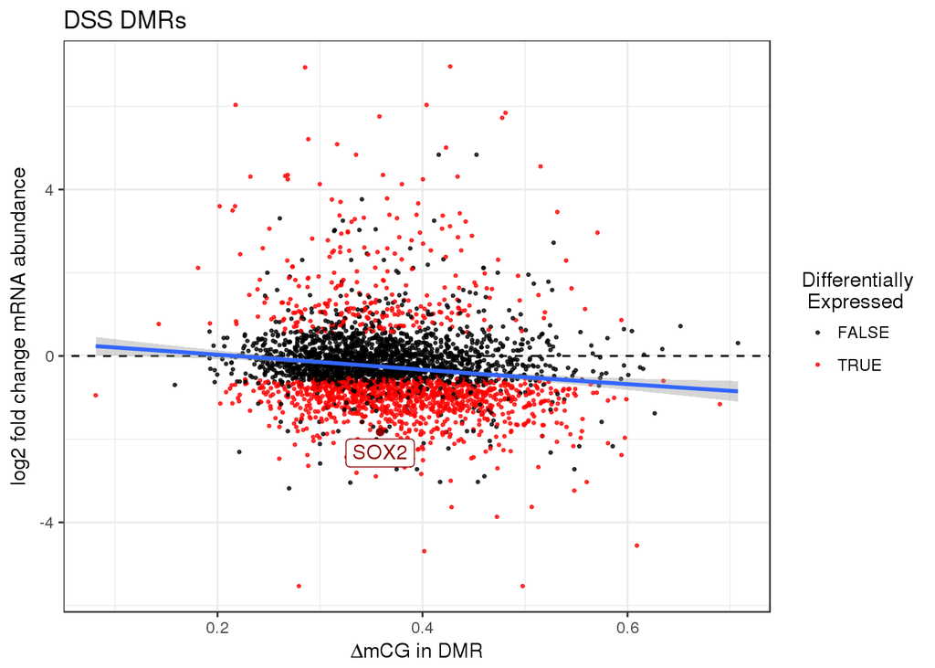

```r
dmrsa <- data.frame(dmrs@listData) %>%
  mutate(sig = padj < fdrlevel.de,
         FC = 2^log2FoldChange,
         delta_mC = meanDiff) %>%
  mutate(A = 0.5*(log2(baseMean) +
               log2(FC*baseMean))) %>%
  mutate(ABin = ntile(A, 9)) %>%
  filter(!is.na(log2FoldChange) & !is.na(sig)) %>%
  filter(delta_mC > 0)

ggplot(dmrsa, aes(x = delta_mC, y = log2FoldChange)) +
  geom_hline(yintercept=0, col="black") +
  geom_hline(yintercept=0, col="white", linetype="dashed") +
  geom_point(size=0.5, alpha=0.75, aes(color = sig)) +
  theme_bw() +
  xlab(expression(paste(Delta, "mCG in DMR"))) +
  ylab("log2 fold change mRNA abundance") +
  scale_color_manual(values=c("black", "red")) +
  #geom_smooth(data=dmrsa %>% filter(sig==TRUE)) +
  geom_smooth() +
  labs(color="Differentially\n Expressed")  +
  geom_point(data =  dmrsa[dmrsa$gene == "SOX2",], col="darkred") +
  geom_label(data =  dmrsa[dmrsa$gene == "SOX2",], col="darkred",
            aes(label="SOX2"), hjust=0.5, vjust=1.25) +
  ggtitle("DSS DMRs")
```

From this figure it is not very clear that most DE genes are down-regulated. There doesn’t seem to be much of a trend for larger magnitude expression differences with larger magnitude methylation differences.

## 6.3 Figure 5B for DSS DMRs

First in the style of the paper:

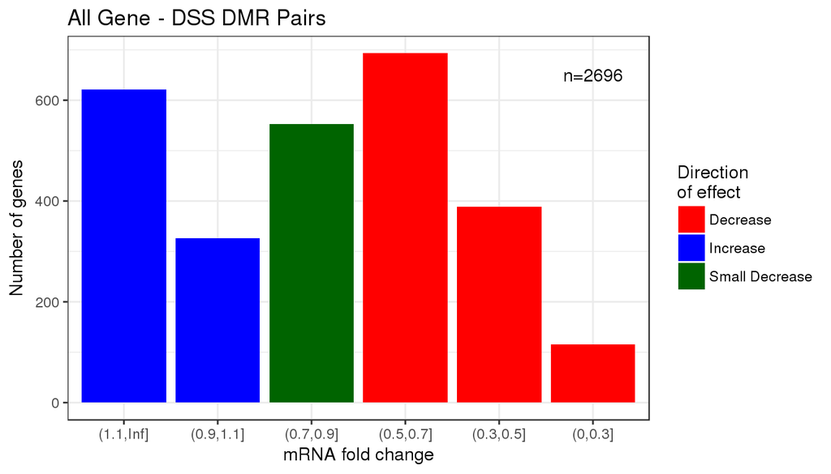

```r
dmrsb <- dmrsa %>%
  filter(delta_mC > 0.3) %>%
  mutate(FCcat = cut(FC,
                     breaks=c(0,0.3,0.5,0.7,0.9,1.1,Inf))) %>%
  mutate(color = ifelse(FCcat %in% c("(0.9,1.1]", "(1.1,Inf]"), "Increase",
                        ifelse(FCcat == "(0.7,0.9]", "Small Decrease", "Decrease"))) %>%
  mutate(FCcat = factor(FCcat, levels = rev(levels(FCcat))))

ggplot(dmrsb, aes(FCcat, fill = color)) +
  geom_bar() +
  theme_bw() +
  scale_fill_manual(values=c("red", "blue", "darkgreen")) +
  xlab("mRNA fold change") +
  ylab("Number of genes") +
  ggtitle("All Gene - DSS DMR Pairs") +
  annotate("text", x = 6, y = 650, label = paste0("n=",nrow(dmrsb))) +
  labs(fill="Direction \nof effect")
```

How many genes had a decrease compared to an increase overall?

```r
de_dn <- sum(dmrsb$log2FoldChange < 0, na.rm=TRUE)
de_up <- sum(dmrsb$log2FoldChange > 0, na.rm=TRUE)
```

Looks like there are 1924 decreased genes and 772 increased genes, where the proportion decreased is 0.714 and the odds of decrease is 2.49.

Next in the improved symmetrical style and separating by DE status:

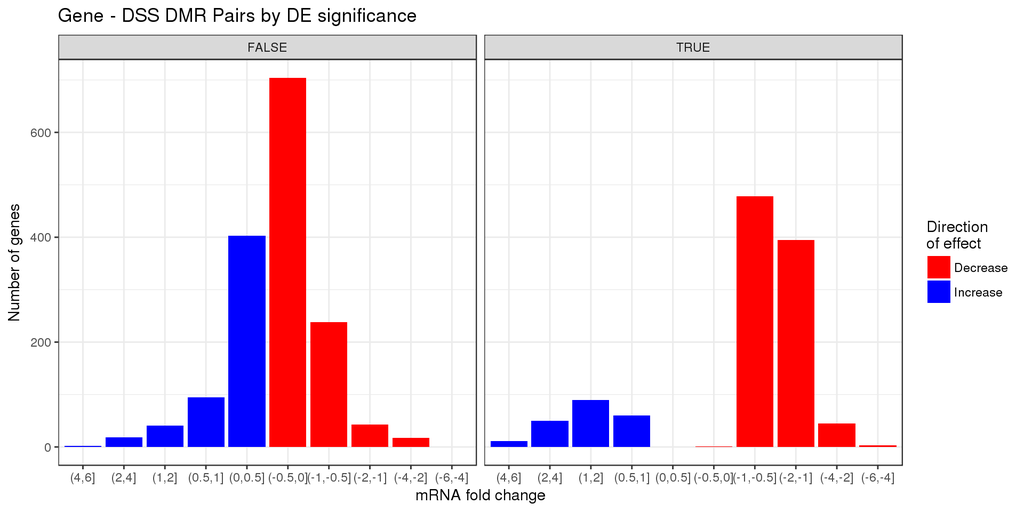

```r
dmrsc <- dmrsa %>%
  filter(delta_mC > 0.3) %>%
  mutate(sig = padj < fdrlevel.de) %>%
  mutate(color = ifelse(log2FoldChange > 0, "Increase", "Decrease")) %>%
  mutate(FCcat = cut(log2FoldChange, breaks = c(-6,-4,-2,-1,-0.5,0,0.5,1,2,4,6))) %>%
  mutate(FCcat = factor(FCcat, levels = rev(levels(FCcat)))) %>%
  na.omit()

ggplot(dmrsc, aes(FCcat, fill = color)) +
  geom_bar() +
  facet_wrap( ~ sig) +
  theme_bw() +
  scale_fill_manual(values=c("red", "blue", "darkgreen")) +
  xlab("mRNA fold change") +
  ylab("Number of genes") +
  ggtitle("Gene - DSS DMR Pairs by DE significance") +
  labs(fill="Direction \nof effect")
```

How many DE genes had a decrease compared to an increase overall?

```r
de_dn <- sum(dmrsc$sig & dmrsc$log2FoldChange < 0, na.rm=TRUE)
de_up <- sum(dmrsc$sig & dmrsc$log2FoldChange > 0, na.rm=TRUE)
```

Looks like there are 922 decreased DE genes and 211 increased DE genes, where the proportion decreased is 0.814 and the odds of decrease is 4.37.

# 7 Reproduce figures for dmrseq DMRs

Here we’ll reproduce the figures using the DMRs found using dmrseq.

## 7.1 Associate dmrseq DMRs with genes

Next we need to associate each DMR with a gene by checking overlap with promoters. We’ll grab the promoter annotation using annotatr.

```r
annot = build_annotations(genome = 'hg19', annotations = 'hg19_genes_promoters')
```

```
## Building promoters...
```

```r
regions.sig <- regions[regions$qval < fdrlevel.dmr,]

ol <- distanceToNearest(regions.sig, annot)

dmrs <- regions.sig[ol@from[mcols(ol)$distance <= 2000],]
dmrs$gene <- annot$symbol[ol@to[mcols(ol)$distance <= 2000]]

dmrs <- dmrs[!is.na(dmrs$gene),]
```

Now that we have a set of DMR-Gene associations, we’ll add the the DE information to the DMR data frame.

```r
# add DE results
x <- match(dmrs$gene, rownames(res))
dmrs <- dmrs[!is.na(x),]
x <- x[!is.na(x)]
res.dmrs <- res[x,]

dmrs <- cbind(dmrs, res.dmrs)
```

## 7.2 Figure 5A for dmrseq DMRs

Now we create the scatterplot like Figure 5A for dmrs.

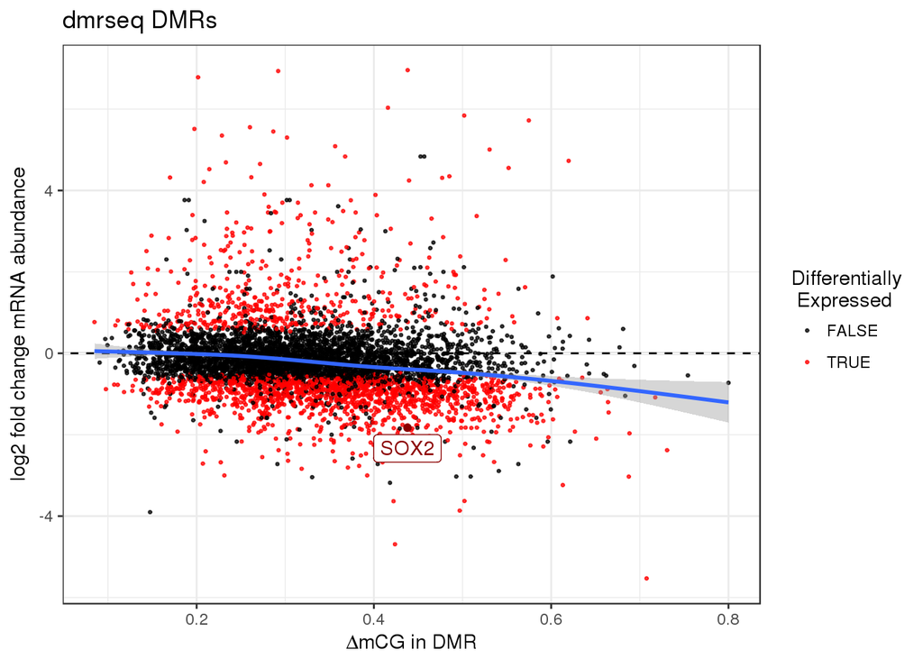

```r
dmrsa <- data.frame(dmrs@listData) %>%
  mutate(sig = padj < fdrlevel.de,
         FC = 2^log2FoldChange,
         delta_mC = meanDiff) %>%
  mutate(A = 0.5*(log2(baseMean) +
               log2(FC*baseMean))) %>%
  mutate(ABin = ntile(A, 9)) %>%
  filter(!is.na(log2FoldChange) & !is.na(sig)) %>%
  filter(delta_mC > 0)

ggplot(dmrsa, aes(x = delta_mC, y = log2FoldChange)) +
  geom_hline(yintercept=0, col="black") +
  geom_hline(yintercept=0, col="white", linetype="dashed") +
  geom_point(size=0.5, alpha=0.75, aes(color = sig)) +
  theme_bw() +
  xlab(expression(paste(Delta, "mCG in DMR"))) +
  ylab("log2 fold change mRNA abundance") +
  scale_color_manual(values=c("black", "red")) +
  #geom_smooth(data=dmrsa %>% filter(sig==TRUE)) +
  geom_smooth() +
  labs(color="Differentially\n Expressed")  +
  geom_point(data =  dmrsa[dmrsa$gene == "SOX2",], col="darkred") +
  geom_label(data =  dmrsa[dmrsa$gene == "SOX2",], col="darkred",
            aes(label="SOX2"), hjust=0.5, vjust=1.25) +
  ggtitle("dmrseq DMRs")
```

From this figure it is a little more clear that most DE genes are down-regulated. But there doesn’t seem to be much of a trend for larger magnitude expression differences with larger magnitude methylation differences.

## 7.3 Figure 5B for dmrseq DMRs

First in the style of the paper:

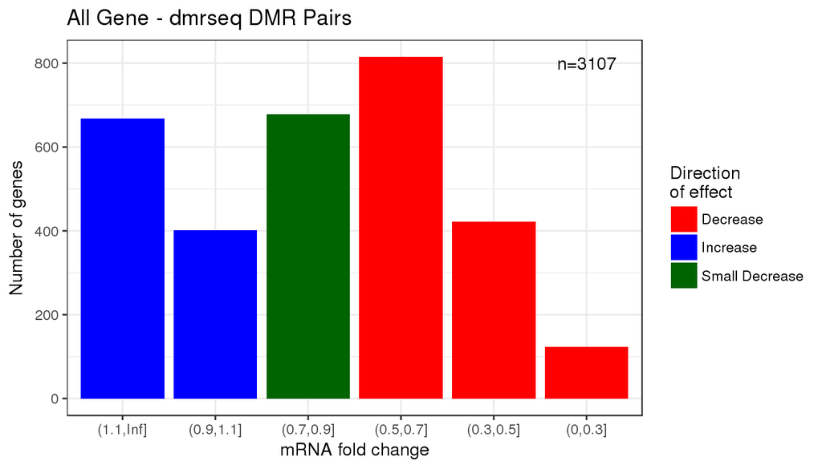

```r
dmrsb <- dmrsa %>%
  filter(delta_mC > 0.3) %>%
  mutate(FCcat = cut(FC,
                     breaks=c(0,0.3,0.5,0.7,0.9,1.1,Inf))) %>%
  mutate(color = ifelse(FCcat %in% c("(0.9,1.1]", "(1.1,Inf]"), "Increase",
                        ifelse(FCcat == "(0.7,0.9]", "Small Decrease", "Decrease"))) %>%
  mutate(FCcat = factor(FCcat, levels = rev(levels(FCcat))))

ggplot(dmrsb, aes(FCcat, fill = color)) +
  geom_bar() +
  theme_bw() +
  scale_fill_manual(values=c("red", "blue", "darkgreen")) +
  xlab("mRNA fold change") +
  ylab("Number of genes") +
  ggtitle("All Gene - dmrseq DMR Pairs") +
  annotate("text", x = 6, y = 800, label = paste0("n=",nrow(dmrsb))) +
  labs(fill="Direction \nof effect")
```

How many genes had a decrease compared to an increase overall?

```r
de_dn <- sum(dmrsb$log2FoldChange < 0, na.rm=TRUE)
de_up <- sum(dmrsb$log2FoldChange > 0, na.rm=TRUE)
```

Looks like there are 2267 decreased genes and 840 increased genes, where the proportion decreased is 0.73 and the odds of decrease is 2.7.

Next in the improved symmetrical style and separating by DE status:

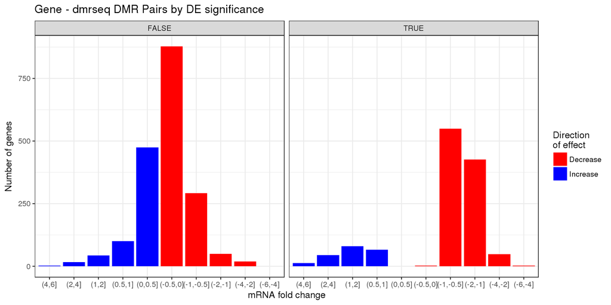

```r
dmrsc <- dmrsa %>%
  filter(delta_mC > 0.3) %>%
  mutate(sig = padj < fdrlevel.de) %>%
  mutate(color = ifelse(log2FoldChange > 0, "Increase", "Decrease")) %>%
  mutate(FCcat = cut(log2FoldChange, breaks = c(-6,-4,-2,-1,-0.5,0,0.5,1,2,4,6))) %>%
  mutate(FCcat = factor(FCcat, levels = rev(levels(FCcat)))) %>%
  na.omit()

ggplot(dmrsc, aes(FCcat, fill = color)) +
  geom_bar() +
  facet_wrap( ~ sig) +
  theme_bw() +
  scale_fill_manual(values=c("red", "blue", "darkgreen")) +
  xlab("mRNA fold change") +
  ylab("Number of genes") +
  ggtitle("Gene - dmrseq DMR Pairs by DE significance") +
  labs(fill="Direction \nof effect")
```

How many DE genes had a decrease compared to an increase overall?

```r
de_dn <- sum(dmrsc$sig & dmrsc$log2FoldChange < 0, na.rm=TRUE)
de_up <- sum(dmrsc$sig & dmrsc$log2FoldChange > 0, na.rm=TRUE)
```

Looks like there are 1028 decreased DE genes and 203 increased DE genes, where the proportion decreased is 0.835 and the odds of decrease is 5.06.

# 8 Alternate version of figures for dmrseq DMRs

Here we’ll create alternate versions of these figures using region level signal as determined from the region level summary statistic of dmrseq. This should be more robust than ordering regions simply on their average methylation difference as was done in the paper. However, note that we cannot do this for DSS DMRS or UMRs, since they do not have region-level statistics available.

## 8.1 Alternate Figure 5A for dmrseq DMRs

Now we create the scatterplot like Figure 5A for dmrs, but replacing the x-axis with the region-level test statistic instead of the methylation difference estimate.

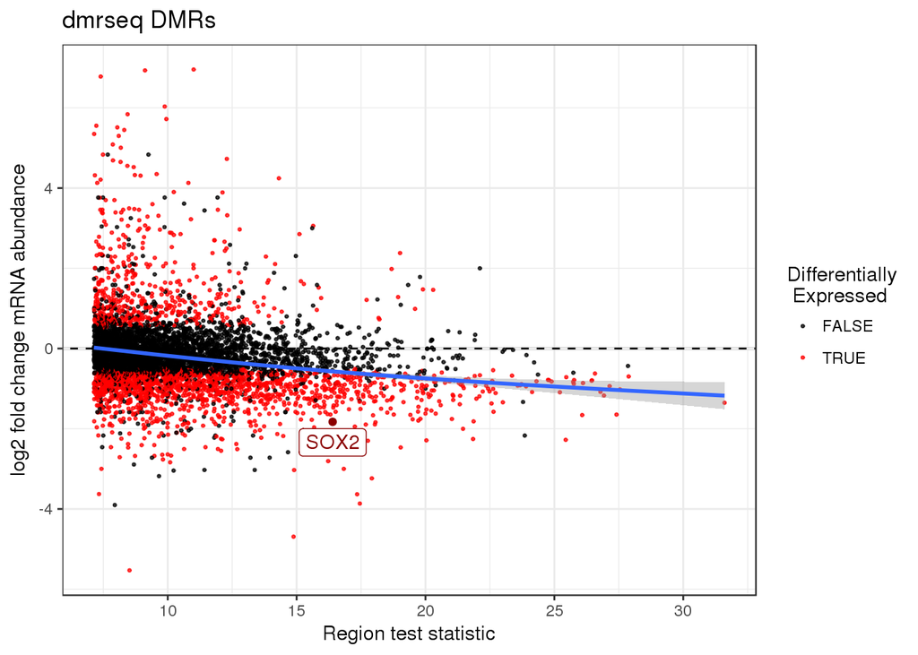

```r
dmrsa <- data.frame(dmrs@listData) %>%
  mutate(sig = padj < fdrlevel.de,
         FC = 2^log2FoldChange,
         delta_mC = meanDiff) %>%
  mutate(A = 0.5*(log2(baseMean) +
               log2(FC*baseMean))) %>%
  mutate(ABin = ntile(A, 9)) %>%
  filter(!is.na(log2FoldChange) & !is.na(sig)) %>%
  filter(delta_mC > 0)

ggplot(dmrsa, aes(x = stat, y = log2FoldChange)) +
  geom_hline(yintercept=0, col="black") +
  geom_hline(yintercept=0, col="white", linetype="dashed") +
  geom_point(size=0.5, alpha=0.75, aes(color = sig)) +
  theme_bw() +
  xlab("Region test statistic") +
  ylab("log2 fold change mRNA abundance") +
  scale_color_manual(values=c("black", "red")) +
  #geom_smooth(data=dmrsa %>% filter(sig==TRUE)) +
  geom_smooth() +
  labs(color="Differentially\n Expressed")  +
  geom_point(data =  dmrsa[dmrsa$gene == "SOX2",], col="darkred") +
  geom_label(data =  dmrsa[dmrsa$gene == "SOX2",], col="darkred",
            aes(label="SOX2"), hjust=0.5, vjust=1.25) +
  ggtitle("dmrseq DMRs")
```

From this figure it is much more clear that most DE genes are down-regulated.

## 8.2 Alternate versions of Figure 5B for dmrseq DMRs

First in the style of the paper:

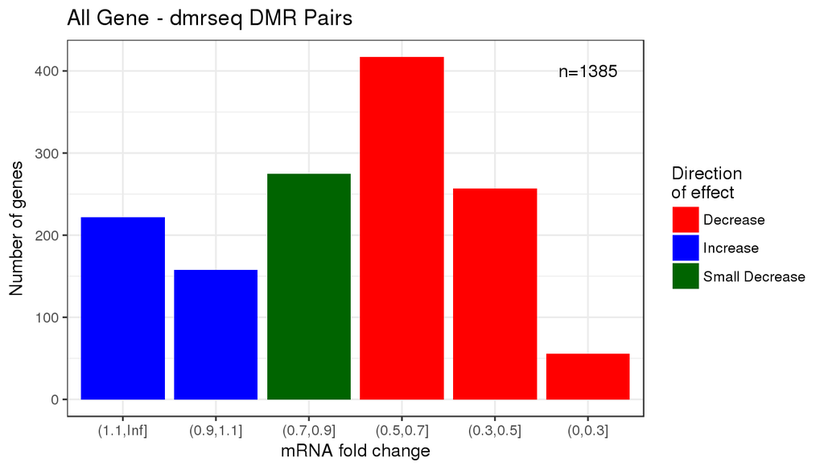

```r
dmrsb <- dmrsa %>%
  filter(stat > 12) %>%
  mutate(FCcat = cut(FC,
                     breaks=c(0,0.3,0.5,0.7,0.9,1.1,Inf))) %>%
  mutate(color = ifelse(FCcat %in% c("(0.9,1.1]", "(1.1,Inf]"), "Increase",
                        ifelse(FCcat == "(0.7,0.9]", "Small Decrease", "Decrease"))) %>%
  mutate(FCcat = factor(FCcat, levels = rev(levels(FCcat))))

ggplot(dmrsb, aes(FCcat, fill = color)) +
  geom_bar() +
  theme_bw() +
  scale_fill_manual(values=c("red", "blue", "darkgreen")) +
  xlab("mRNA fold change") +
  ylab("Number of genes") +
  ggtitle("All Gene - dmrseq DMR Pairs") +
  annotate("text", x = 6, y = 400, label = paste0("n=",nrow(dmrsb))) +
  labs(fill="Direction \nof effect")
```

How many genes had a decrease compared to an increase overall?

```r
de_dn <- sum(dmrsb$log2FoldChange < 0, na.rm=TRUE)
de_up <- sum(dmrsb$log2FoldChange > 0, na.rm=TRUE)
```

Looks like there are 1095 decreased genes and 290 increased genes, where the proportion decreased is 0.791 and the odds of decrease is 3.78.

Next in the improved symmetrical style and separating by DE status:

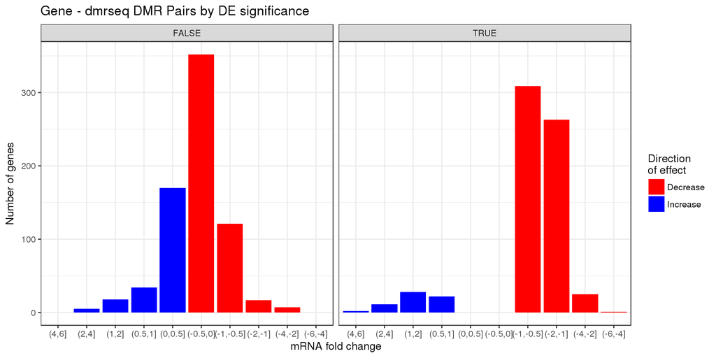

```r
dmrsc <- dmrsa %>%
  filter(stat > 12) %>%
  mutate(sig = padj < fdrlevel.de) %>%
  mutate(color = ifelse(log2FoldChange > 0, "Increase", "Decrease")) %>%
  mutate(FCcat = cut(log2FoldChange, breaks = c(-6,-4,-2,-1,-0.5,0,0.5,1,2,4,6))) %>%
  mutate(FCcat = factor(FCcat, levels = rev(levels(FCcat)))) %>%
  na.omit()

ggplot(dmrsc, aes(FCcat, fill = color)) +
  geom_bar() +
  facet_wrap( ~ sig) +
  theme_bw() +
  scale_fill_manual(values=c("red", "blue", "darkgreen")) +
  xlab("mRNA fold change") +
  ylab("Number of genes") +
  ggtitle("Gene - dmrseq DMR Pairs by DE significance") +
  labs(fill="Direction \nof effect")
```

How many DE genes had a decrease compared to an increase overall?

```r
de_dn <- sum(dmrsc$sig & dmrsc$log2FoldChange < 0, na.rm=TRUE)
de_up <- sum(dmrsc$sig & dmrsc$log2FoldChange > 0, na.rm=TRUE)
```

Looks like there are 598 decreased DE genes and 63 increased DE genes, where the proportion decreased is 0.905 and the odds of decrease is 9.49.